# Homework Sberbank

Solonin Maxim

19 12 2016

# Домашняя работа Сбербанк

## Разведочный анализ данных

Сначала необходимо взглянуть на данные, что они в себе содержат. Основные данные представляют из себя историю банковских транзакций, а также демографическую информацию (пол) по некоторой выборке клиентов. В ходе анализа будут даны ответы на несколько вопросов по текущему датасету, а также построены несколько моделей, которые предсказывают пол клиента по его банковским операциям (транзакциям). Модель, демонстрирующая лучшие результаты, будет использована для предсказания пола 3000 клиентов из независимой выборки.

| customer_id | tr_datetime | mcc_code | tr_type | amount | term_id |
| --- | --- | --- | --- | --- | --- |
| 39026145 | 0 10:23:26 | 4814 | 1030 | -100 | NA |
| 39026145 | 1 10:19:29 | 6011 | 7010 | 2500 | NA |
| 39026145 | 1 10:20:56 | 4829 | 2330 | -2500 | NA |
| 39026145 | 1 10:39:54 | 5499 | 1010 | -62 | NA |
| 39026145 | 2 15:33:42 | 5499 | 1010 | -41 | NA |
| 39026145 | 2 15:53:49 | 5541 | 1010 | -652 | NA |

| customer_id | gender |
| --- | --- |
| 83810118 | 0 |
| 44338675 | 0 |
| 85577609 | 0 |
| 74944537 | 0 |
| 9118054 | 0 |
| 70473209 | 1 |

Мы посмотрели на основные данные, которые будем использовать, также есть вспомогательная информация, описывающая mcc-коды транзакций и тип банковской транзакции.

| mcc_code | mcc_description |
| --- | --- |
| 742 | Ветеринарные услуги |
| 1711 | Генеральные подрядчики по вентиляции, теплоснабжению, и водопроводу |
| 1731 | Подрядчики по электричеству |
| 1799 | Подрядчики, специализированная торговля — нигде более не классифицированные |
| 2741 | Разнообразные издательства/печатное дело |
| 3000 | Авиалинии, авиакомпании |

| tr_type | tr_description |
| --- | --- |
| 3200 | Плата за предоставление услуг посредством мобильной связи |
| 3210 | Плата за предоставление отчета по счету карты почтой |
| 3800 | Плата за обслуживание банковской карты (за первый год) |
| 4000 | Плата за получение наличных в Сбербанке |

Теперь рассмотрим базовые закономерности в данных.

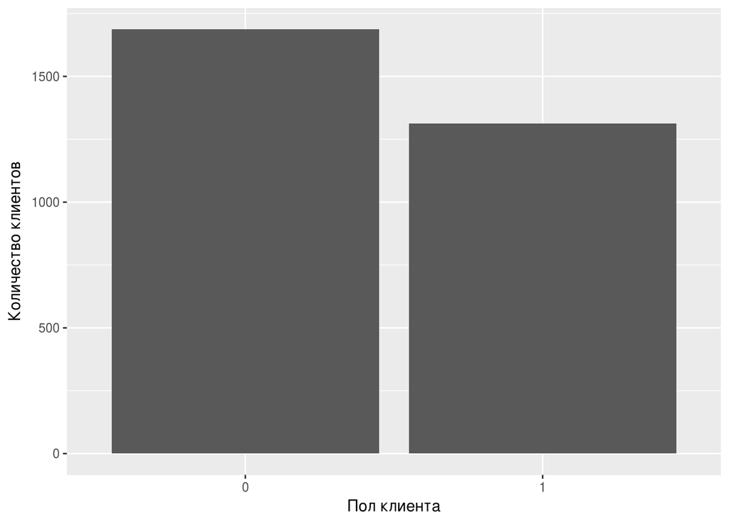

Так, из 3000 клиентов в наших данных 1688 - женщины и 1312 - мужчины. В основном пол клиента можно определить по описанию mcc-кода транзакции, потому что это может сообщить о деятельности человека - ходит он в салон красоты, покупает снегоход и т.д. Выделим самые популярные виды операций:

| mcc_code | mcc_description | count |
| --- | --- | --- |
| 6011 | Финансовые институты — снятие наличности автоматически | 290727 |
| 6010 | Финансовые институты — снятие наличности вручную | 289252 |
| 4814 | Звонки с использованием телефонов, считывающих магнитную ленту | 199714 |
| 5411 | Бакалейные магазины, супермаркеты | 191430 |
| 4829 | Денежные переводы | 123259 |
| 5499 | Различные продовольственные магазины — рынки, магазины со спец-ассортиментом, продажа полуфабрикатов, фирменных блюд, продажа с помощью торговых автоматов | 68422 |
| 5541 | Станции техобслуживания | 27020 |
| 5912 | Аптеки | 25551 |
| 5331 | Универсальные магазины | 25113 |
| 5812 | Места общественного питания, рестораны | 21946 |

Можно заметить, что в 10 самых популярных видах транзакций нет, на мой взгляд, ничего явно классифицируещего клиентов по полу. Таким образом, самые популярные виды транзакций не помогут сделать вывод о поле клиента.

Что касается доходов и расходов, стоит отметить, что в данной выборке клиенты больше тратят, чем получают дохода.

Посмотрим, существуют ли какие-то временные паттерны в транзакциях. По совету 153 день задается как 1 января 2015. Интересно, как это было определено. Построим график, показывающий количество транзакций по каждому дню из массива данных.

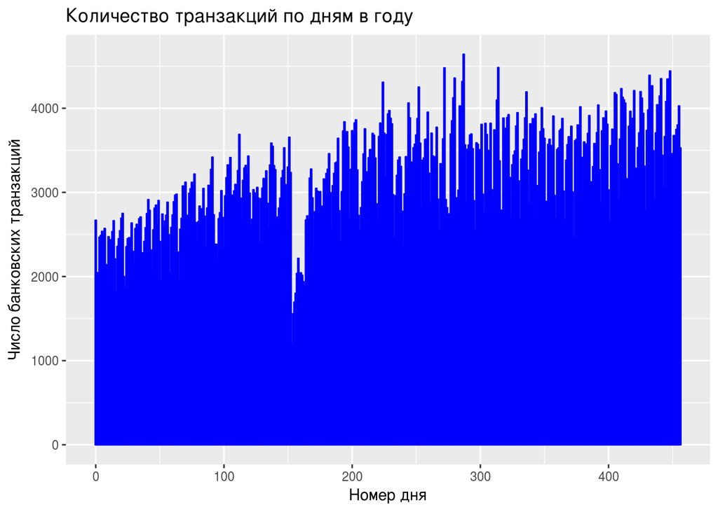

Очень заметен сильный спад количества транзакций 1 раз за эти 457 дней. Можно догадаться, что это как раз тот самый 153 день, но по этому графику точный номер дня не увидеть, посмотрим поближе.

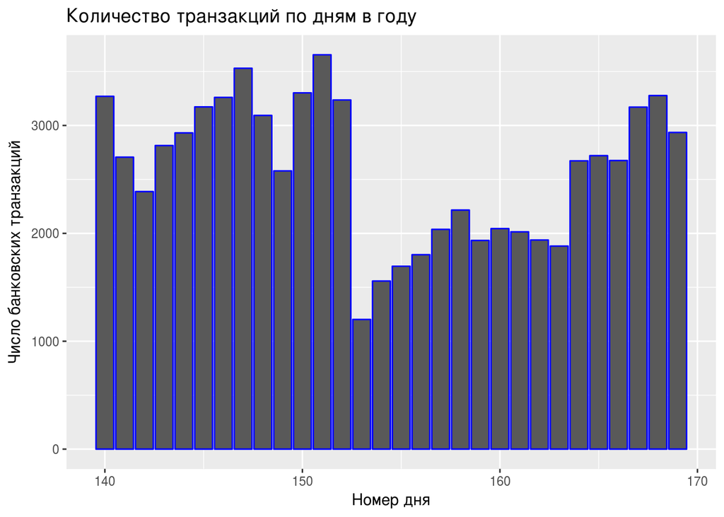

Так и оказалось, 153 день демонстрирует минимальное количество банковских транзакций, что может быть непосредственно связано с закрытыми отделениями Сбербанка, большинства магазинов, а также празднование людьми Нового Года. Таким образом, можно определить, что 153 день соответствует 1 января.

Заметно, что количество транзакций колеблется с определенным периодом. Интересно посмотреть, есть ли этому какое-то объяснение. Поскольку просматривается цикличность, напоминающая недельную, построим графики количества транзакций по дням недели. Сначала возьмем отдельный месяц.

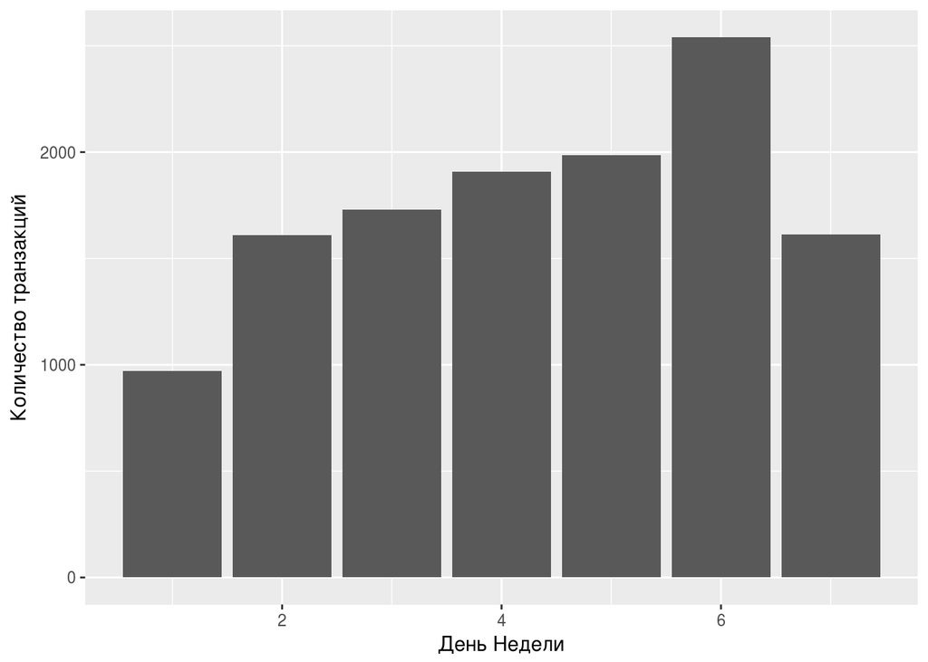

Оказывается, что в первый месяц наших данных больше всего транзакций совершалось в субботу. Посмотрим, подтвердится ли это на всем массиве данных.

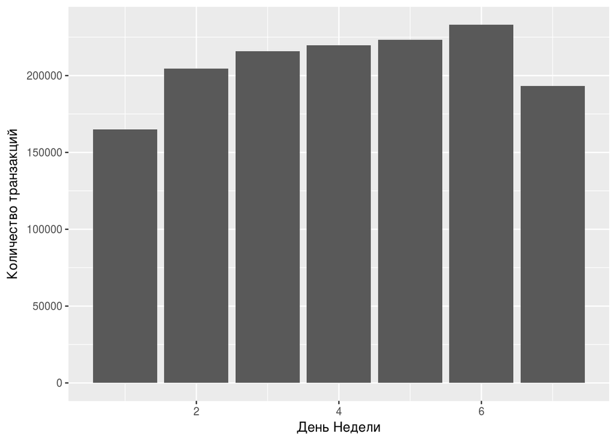

Так и оказалось. В течение 457 дней, которые есть у нас в массиве, клиенты чаще всего совершали транзакции по субботам. Это можно объяснить тем, что в субботу у многих людей выходной и есть время на совершение различных транзакций.

Посмотрим, есть ли какой-нибудь паттерн по месяцам.

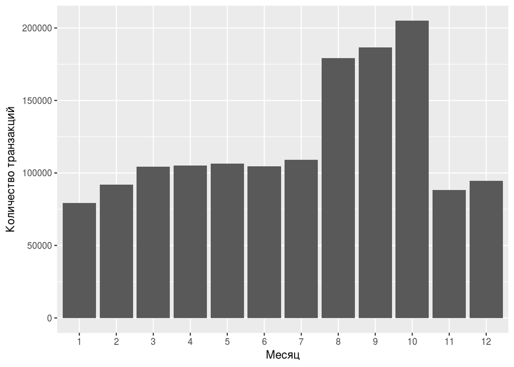

Может показаться, что люди совершают больше транзакций с августа по октябрь. Однако, это всего лишь особенность наших данных, они начались с августа 2014 и закончились в конце октября 2015. Следовательно, в данных дважды встречаются эти 3 месяца и нет ничего удивительного в таком разбросе.

## Предсказание пола клиента по банковским операциям

Сначала отформатируем датасет, чтобы он был пригоден для предсказания пола клиентов.

После этого разделим тренировочный массив на обучающую и тестовую выборки в соотношении 80 к 20 и построим дерево для предсказаний.

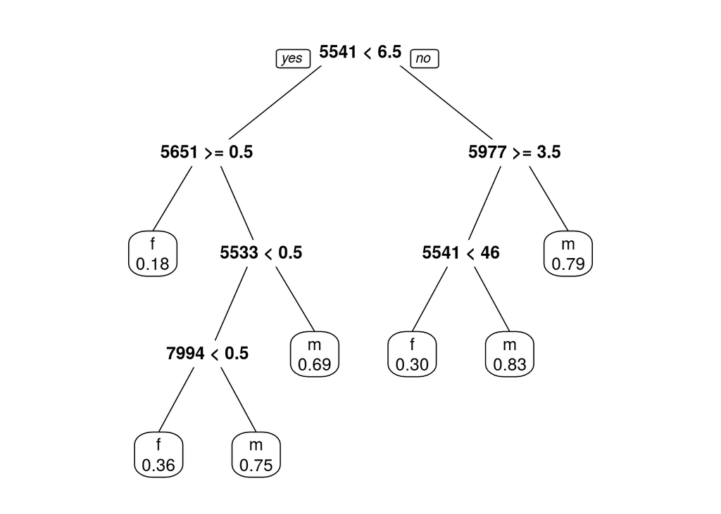

Построенное дерево предсказывает пол клиентов и показывает вероятность с которой клиент, попавший в определенную вершину дерева, окажется мужчиной.

| Accuracy | AccuracyLower | AccuracyUpper |
| --- | --- | --- |
| 0.7204 | 0.702 | 0.7383 |

Общая точность модели на обучающей выборке 0.72, что достаточно неплохо. Проверим, как наша модель работает на тестовой выборке.

| Accuracy | AccuracyLower | AccuracyUpper |
| --- | --- | --- |
| 0.695 | 0.6564 | 0.7316 |

Точность немного снизилась, теперь она равна 0.695.

Теперь используем другой метод для предсказания пола - метод опорных векторов.

| Accuracy | AccuracyLower | AccuracyUpper |
| --- | --- | --- |
| 0.7937 | 0.777 | 0.8098 |

Метод опорных векторов показал лучшую точность по сравнению с деревом решений. Однако, при проверке на тестовой выборке разница оказалась не столь значительна.

| Accuracy | AccuracyLower | AccuracyUpper |
| --- | --- | --- |
| 0.6983 | 0.6599 | 0.7348 |

Теперь попробуем убрать топ-12 транзакций, которые являются достаточно общими для клиентов обоих полов, а также 4 самые редкие, которые несильно помогут в предсказании пола.

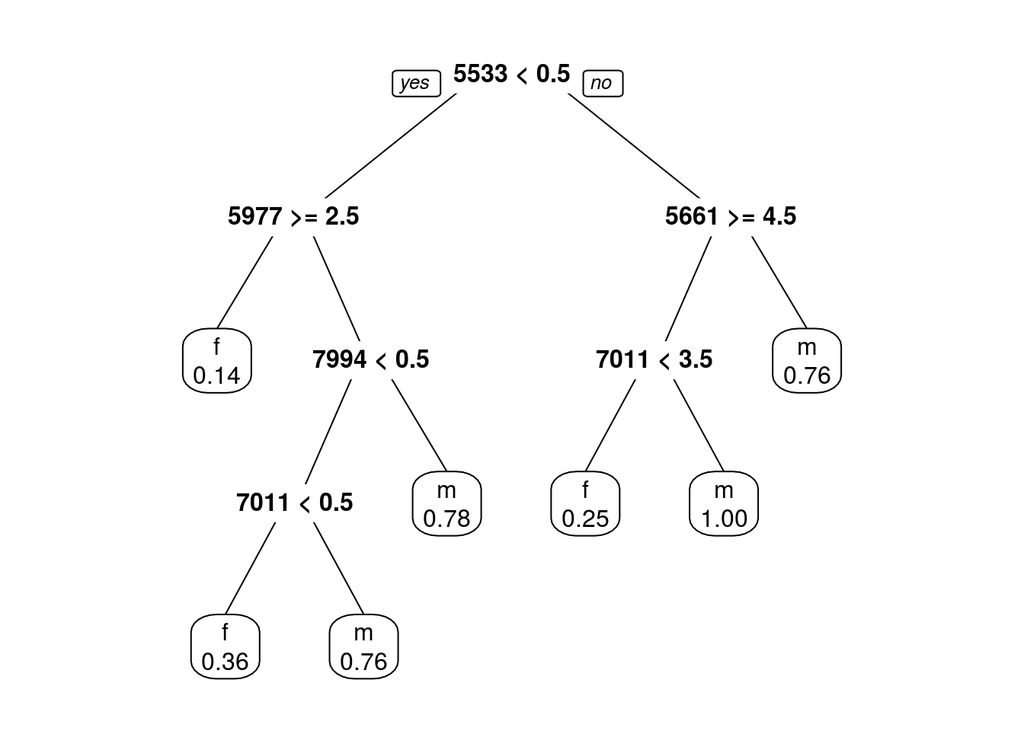

Посмотрим на точность предсказания этого дерева.

На обучающей выборке:

| Accuracy | AccuracyLower | AccuracyUpper |
| --- | --- | --- |
| 0.7096 | 0.691 | 0.7277 |

На тестовой:

| Accuracy | AccuracyLower | AccuracyUpper |
| --- | --- | --- |
| 0.6633 | 0.624 | 0.7011 |

Таким образом, это дерево предсказывает хуже, чем дерево со всеми mcc-кодами.

Теперь проанализируем этот массив с помощью метода опорных векторов.

| Accuracy | AccuracyLower | AccuracyUpper |
| --- | --- | --- |
| 0.7704 | 0.7531 | 0.7871 |

Данная модель лучше обоих деревьев решений, однако уступает по точности методу опорных векторов по всем переменным. Проверим ее на тестовой выборке.

| Accuracy | AccuracyLower | AccuracyUpper |
| --- | --- | --- |
| 0.6917 | 0.653 | 0.7284 |

Таким образом, точность получилась ниже в сравнении с моделью со всеми переменными.

Используем метод главных компонент, чтобы снизить размерность.

Результат на обучающей:

| Accuracy | Kappa | AccuracyLower | AccuracyUpper | AccuracyNull |
| --- | --- | --- | --- | --- |
| 0.7829 | 0.5396 | 0.7659 | 0.7993 | 0.5571 |

Результат на тестовой:

| Accuracy | Kappa | AccuracyLower | AccuracyUpper | AccuracyNull |
| --- | --- | --- | --- | --- |
| 0.6783 | 0.2952 | 0.6393 | 0.7156 | 0.585 |

Таким образом, эта модель со сниженной размерностью обладает меньшей точностью, чем первая.

Результаты на обучающей выборке:

| Accuracy | Kappa | AccuracyLower | AccuracyUpper | AccuracyNull |
| --- | --- | --- | --- | --- |
| 0.7692 | 0.5109 | 0.7518 | 0.7859 | 0.5571 |

Результаты на тестовой выборке:

| Accuracy | Kappa | AccuracyLower | AccuracyUpper | AccuracyNull |
| --- | --- | --- | --- | --- |
| 0.6883 | 0.3179 | 0.6496 | 0.7252 | 0.585 |

Таким образом, точность модели по сравнению с предыдущей улучшилась, однако все равно хуже, чем изначальный вариант. Использование метода ближайших соседей давало вероятность

| Accuracy | Kappa | AccuracyLower | AccuracyUpper | AccuracyNull |
| --- | --- | --- | --- | --- |
| 0.655 | 0.2588 | 0.6154 | 0.693 | 0.585 |

Метод ближайших соседей также не дал результата лучшего, чем исходная модель. В результате будем применять к тестовому массиву данных изначальную модель по методу опорных векторов.